# Bathing

This is another [R Markdown](http://rmarkdown.rstudio.com) Notebook.

Make sure you’ve already done the “calibration” notebook.

We load the `tidyverse` packages again:

```r
library('tidyverse')
```

We load the bathing data:

```r
bathing = read_csv('bathing.csv')
bathing
```

| town | coliform_mean | coliform_std |
| --- | --- | --- |
| Whitby | 720 | 77.04 |
| Robin Hoods Bay | 1650 | 177.00 |
| Scarborough | 800 | 150.63 |
| Sandsend | 200 | 21.40 |
| Blackpool | 1850 | 197.95 |
| Morecambe | 2500 | 56.00 |
| Bournemouth | 900 | 96.30 |
| Lyme Regis | 750 | 80.25 |
| Sidmouth | 650 | 69.55 |
| Dawlish Warren | 750 | 168.00 |

[output cut: 6 more lines]

We want a bar graph showing the mean coliform concentration for each town. A bar graph has a `geom_` type of `bar`. The `geom_bar` type expects some transformation to apply to the data, to get the bar height. In our case, we want the `coliform_mean` to give the bar height directly, so we don’t want to apply any transformation. For this we use `stat='identity` as the transformation to apply, which does nothing:

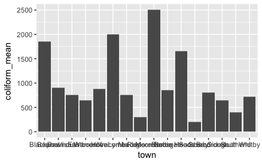

```r
ggplot(bathing, aes(x = town, y = coliform_mean)) +
  geom_bar(stat='identity') # use the mean directly for height
```

The town name x axis labels are a real mess, because they overlap. We would like to angle them, so we can read which town is which on the x axis. Googling will get you the commands you need, but here is what you have to add to rotate the x axis labels:

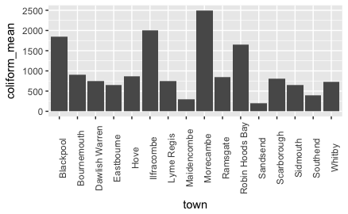

```r
len = bathing$coliform_mean
se = bathing$coliform_std
ggplot(bathing, aes(x = town, y = coliform_mean)) +
  geom_bar(stat="identity") +
  theme(axis.text.x=element_text(angle=90)) # vertical labels
```

We could fiddle with that a bit, to make it prettier, but that’s good enough for now.

Finally, we can add the standard deviation to these bars, using the `geom_errorbar` type. We need to work out the top and bottom of the error bars first though. The tops are the mean plus the standard deviation, and the bottoms are the mean minus the standard deviation. To start, we’ll get the means and standard deviation as lists (vectors) of numbers:

```r
c_mean = bathing$coliform_mean
c_mean
```

```
 [1]  720 1650  800  200 1850 2500  900  750  650  750  300
[12] 2000  850  650  875  400
```

```r
c_std = bathing$coliform_std
c_std
```

```
 [1]  77.04 177.00 150.63  21.40 197.95  56.00  96.30
 [8]  80.25  69.55 168.00 200.00 214.00  90.95  25.00
[15]  93.63  42.80
```

Next we calculate the tops and bottoms of the error bars. Notice that `+` and `-` when applied to these vectors (lists), subtracts the number at position 1 from the number at position 1, the number at position 2 from the number at position 2 and so on:

```r
tops = c_mean + c_std
tops
```

```
 [1]  797.04 1827.00  950.63  221.40 2047.95 2556.00
 [7]  996.30  830.25  719.55  918.00  500.00 2214.00
[13]  940.95  675.00  968.63  442.80
```

```r
bottoms = c_mean - c_std
bottoms
```

```
 [1]  642.96 1473.00  649.37  178.60 1652.05 2444.00
 [7]  803.70  669.75  580.45  582.00  100.00 1786.00
[13]  759.05  625.00  781.37  357.20
```

Now we can plot our error bars, using the `geom_errorbar` type:

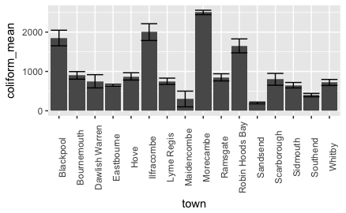

```r
ggplot(bathing, aes(x = town, y = coliform_mean)) +
  geom_bar(stat="identity") +
  geom_errorbar(aes(ymin = bottoms, ymax = tops)) +
  theme(axis.text.x=element_text(angle=90))
```